# Practical Machine Learning - Course Project

Dinesh Srivastava

Wednesday, October 22, 2014

# Predict the manner in which the Weight Lifting Exercises are done.

### I. Synopsis

Using devices such as Jawbone Up, Nike FuelBand, and Fitbit it is now possible to collect a large amount of data about personal activity relatively inexpensively. These type of devices are part of the quantified self movement - a group of enthusiasts who take measurements about themselves regularly to improve their health, to find patterns in their behavior, or because they are tech geeks. One thing that people regularly do is quantify how much of a particular activity they do, but they rarely quantify how well they do it.

In this project, the goal is to use data from accelerometers on the belt, forearm, arm, and dumbell of 6 participants. They were asked to perform barbell lifts correctly and incorrectly in 5 different ways. The goal of this project is to predict the manner in which they did the exercise.

The *Weight Lifting Exercises Dataset* is harvested from following paper:

Velloso, E.; Bulling, A.; Gellersen, H.; Ugulino, W.; Fuks, H. [Qualitative Activity Recognition of Weight Lifting Exercises](http://groupware.les.inf.puc-rio.br/work.jsf?p1=11201). Proceedings of 4th International Conference in Cooperation with SIGCHI (Augmented Human ’13) . Stuttgart, Germany: ACM SIGCHI, 2013.

### II. General Housekeeping

```r
library(AppliedPredictiveModeling)
library(caret)
library(rattle)
```

```r
library(rpart.plot)
library(randomForest)
```

### III. Downloading and preprocessing data files

*Step 1: Download data files*

```r
if (!file.exists("./pml-training.csv")) {
    download.file("https://d396qusza40orc.cloudfront.net/predmachlearn/pml-training.csv", destfile = "./pml-training.csv")
}

if (!file.exists("./pml-testing.csv")) {
    download.file("https://d396qusza40orc.cloudfront.net/predmachlearn/pml-testing.csv", destfile = "./pml-testing.csv")
}
```

*Step 2: Import data treating empty values as NA*

```r
# Import data while substituting empty values as 'NA'.
        training <- read.csv("./pml-training.csv", na.strings=c("NA",""), header=TRUE)
        colnames_train <- colnames(training)

        testing <- read.csv("./pml-testing.csv", na.strings=c("NA",""), header=TRUE)
        colnames_test <- colnames(testing)

# Verify that the column names (excluding classe and problem_id) are identical in both the training and the test set.
        all.equal(colnames_train[1:length(colnames_train)-1], colnames_test[1:length(colnames_train)-1])
```

```
## [1] TRUE
```

*Step 3: Eliminate columns with ‘NA’ and other columns irrelavent to the prediction, such as, ‘user_name’, ‘timestamp’, ‘new_window’, etc.*

```r
# Count the number of non-NAs in each column
        nonNAs <- function(x) {
                as.vector(apply(x, 2, function(x) length(which(!is.na(x)))))
                }

# Build vector of missing data or NA columns to drop.
        colcnts <- nonNAs(training)
        drops <- c()
        for (cnt in 1:length(colcnts)) {
                if (colcnts[cnt] < nrow(training)) {
                        drops <- c(drops, colnames_train[cnt])
                        }
                }

# Drop NA data and the first 7 columns as they are unnecessary for prediction.
        training <- training[,!(names(training) %in% drops)]
        training <- training[,8:length(colnames(training))]

        testing <- testing[,!(names(testing) %in% drops)]
        testing <- testing[,8:length(colnames(testing))]

# Show columns of final data sets.
        colnames(training)
```

```
##  [1] "roll_belt"            "pitch_belt"           "yaw_belt"
##  [4] "total_accel_belt"     "gyros_belt_x"         "gyros_belt_y"
##  [7] "gyros_belt_z"         "accel_belt_x"         "accel_belt_y"
## [10] "accel_belt_z"         "magnet_belt_x"        "magnet_belt_y"
## [13] "magnet_belt_z"        "roll_arm"             "pitch_arm"
## [16] "yaw_arm"              "total_accel_arm"      "gyros_arm_x"
## [19] "gyros_arm_y"          "gyros_arm_z"          "accel_arm_x"
## [22] "accel_arm_y"          "accel_arm_z"          "magnet_arm_x"
## [25] "magnet_arm_y"         "magnet_arm_z"         "roll_dumbbell"
## [28] "pitch_dumbbell"       "yaw_dumbbell"         "total_accel_dumbbell"
## [31] "gyros_dumbbell_x"     "gyros_dumbbell_y"     "gyros_dumbbell_z"
## [34] "accel_dumbbell_x"     "accel_dumbbell_y"     "accel_dumbbell_z"
## [37] "magnet_dumbbell_x"    "magnet_dumbbell_y"    "magnet_dumbbell_z"
## [40] "roll_forearm"         "pitch_forearm"        "yaw_forearm"
## [43] "total_accel_forearm"  "gyros_forearm_x"      "gyros_forearm_y"
## [46] "gyros_forearm_z"      "accel_forearm_x"      "accel_forearm_y"
## [49] "accel_forearm_z"      "magnet_forearm_x"     "magnet_forearm_y"
## [52] "magnet_forearm_z"     "classe"
```

```r
        colnames(testing)
```

```
##  [1] "roll_belt"            "pitch_belt"           "yaw_belt"
##  [4] "total_accel_belt"     "gyros_belt_x"         "gyros_belt_y"
##  [7] "gyros_belt_z"         "accel_belt_x"         "accel_belt_y"
## [10] "accel_belt_z"         "magnet_belt_x"        "magnet_belt_y"
## [13] "magnet_belt_z"        "roll_arm"             "pitch_arm"
## [16] "yaw_arm"              "total_accel_arm"      "gyros_arm_x"
## [19] "gyros_arm_y"          "gyros_arm_z"          "accel_arm_x"
## [22] "accel_arm_y"          "accel_arm_z"          "magnet_arm_x"
## [25] "magnet_arm_y"         "magnet_arm_z"         "roll_dumbbell"
## [28] "pitch_dumbbell"       "yaw_dumbbell"         "total_accel_dumbbell"
## [31] "gyros_dumbbell_x"     "gyros_dumbbell_y"     "gyros_dumbbell_z"
## [34] "accel_dumbbell_x"     "accel_dumbbell_y"     "accel_dumbbell_z"
## [37] "magnet_dumbbell_x"    "magnet_dumbbell_y"    "magnet_dumbbell_z"
## [40] "roll_forearm"         "pitch_forearm"        "yaw_forearm"
## [43] "total_accel_forearm"  "gyros_forearm_x"      "gyros_forearm_y"
## [46] "gyros_forearm_z"      "accel_forearm_x"      "accel_forearm_y"
## [49] "accel_forearm_z"      "magnet_forearm_x"     "magnet_forearm_y"
## [52] "magnet_forearm_z"     "problem_id"
```

*Step 4: Remove near zero covariates*

```r
# Remove near zero covariates
        nsv <- nearZeroVar(training,saveMetrics=TRUE)
        nsv
```

```
##                      freqRatio percentUnique zeroVar   nzv
## roll_belt             1.101904     6.7781062   FALSE FALSE
## pitch_belt            1.036082     9.3772296   FALSE FALSE
## yaw_belt              1.058480     9.9734991   FALSE FALSE
## total_accel_belt      1.063160     0.1477933   FALSE FALSE
## gyros_belt_x          1.058651     0.7134849   FALSE FALSE
## gyros_belt_y          1.144000     0.3516461   FALSE FALSE
## gyros_belt_z          1.066214     0.8612782   FALSE FALSE
## accel_belt_x          1.055412     0.8357966   FALSE FALSE
## accel_belt_y          1.113725     0.7287738   FALSE FALSE
## accel_belt_z          1.078767     1.5237998   FALSE FALSE
## magnet_belt_x         1.090141     1.6664968   FALSE FALSE
## magnet_belt_y         1.099688     1.5187035   FALSE FALSE
## magnet_belt_z         1.006369     2.3290184   FALSE FALSE
## roll_arm             52.338462    13.5256345   FALSE FALSE
## pitch_arm            87.256410    15.7323412   FALSE FALSE
## yaw_arm              33.029126    14.6570176   FALSE FALSE
## total_accel_arm       1.024526     0.3363572   FALSE FALSE
## gyros_arm_x           1.015504     3.2769341   FALSE FALSE
## gyros_arm_y           1.454369     1.9162165   FALSE FALSE
## gyros_arm_z           1.110687     1.2638875   FALSE FALSE
## accel_arm_x           1.017341     3.9598410   FALSE FALSE
## accel_arm_y           1.140187     2.7367241   FALSE FALSE
## accel_arm_z           1.128000     4.0362858   FALSE FALSE
## magnet_arm_x          1.000000     6.8239731   FALSE FALSE
## magnet_arm_y          1.056818     4.4439914   FALSE FALSE
## magnet_arm_z          1.036364     6.4468454   FALSE FALSE
## roll_dumbbell         1.022388    84.2065029   FALSE FALSE
## pitch_dumbbell        2.277372    81.7449801   FALSE FALSE
## yaw_dumbbell          1.132231    83.4828254   FALSE FALSE
## total_accel_dumbbell  1.072634     0.2191418   FALSE FALSE
## gyros_dumbbell_x      1.003268     1.2282132   FALSE FALSE
## gyros_dumbbell_y      1.264957     1.4167771   FALSE FALSE
## gyros_dumbbell_z      1.060100     1.0498420   FALSE FALSE
## accel_dumbbell_x      1.018018     2.1659362   FALSE FALSE
## accel_dumbbell_y      1.053061     2.3748853   FALSE FALSE
## accel_dumbbell_z      1.133333     2.0894914   FALSE FALSE
## magnet_dumbbell_x     1.098266     5.7486495   FALSE FALSE
## magnet_dumbbell_y     1.197740     4.3012945   FALSE FALSE
## magnet_dumbbell_z     1.020833     3.4451126   FALSE FALSE
## roll_forearm         11.589286    11.0895933   FALSE FALSE
## pitch_forearm        65.983051    14.8557741   FALSE FALSE
## yaw_forearm          15.322835    10.1467740   FALSE FALSE
## total_accel_forearm   1.128928     0.3567424   FALSE FALSE
## gyros_forearm_x       1.059273     1.5187035   FALSE FALSE
## gyros_forearm_y       1.036554     3.7763735   FALSE FALSE
## gyros_forearm_z       1.122917     1.5645704   FALSE FALSE
## accel_forearm_x       1.126437     4.0464784   FALSE FALSE
## accel_forearm_y       1.059406     5.1116094   FALSE FALSE
## accel_forearm_z       1.006250     2.9558659   FALSE FALSE
## magnet_forearm_x      1.012346     7.7667924   FALSE FALSE
## magnet_forearm_y      1.246914     9.5403119   FALSE FALSE
## magnet_forearm_z      1.000000     8.5771073   FALSE FALSE
## classe                1.469581     0.0254816   FALSE FALSE
```

```r
        training <- training[,!nsv$nzv]
        testing <- testing[,!nsv$nzv]

#        nsv
```

Given that all of the near zero variance variables (nsv) are FALSE, there’s no need to eliminate any covariates due to lack of variablility.

### IV. Split data to training and testing for cross validation.

```r
        inTrain <- createDataPartition(y=training$classe, p=0.7, list=FALSE)
        new_training <- training[inTrain,]
        new_testing <- training[-inTrain,]

        dim(new_training)
```

```
## [1] 13737    53
```

```r
        dim(new_testing)
```

```
## [1] 5885   53
```

We got 13737 samples and 53 variables for training, 5885 samples and 53 variables for testing.

### V. Analysis

#### 1. Regression Tree

Now we fit a tree to these data, and summarize and plot it. First, we use the ‘tree’ package. It is much faster than ‘caret’ package.

```r
#install.packages("tree")
library(tree)
set.seed(32323)
        tree.training=tree(classe~.,data=new_training)
        summary(tree.training)
```

```
##
## Classification tree:
## tree(formula = classe ~ ., data = new_training)
## Variables actually used in tree construction:
##  [1] "roll_belt"            "pitch_forearm"        "roll_forearm"
##  [4] "magnet_dumbbell_x"    "magnet_dumbbell_y"    "magnet_dumbbell_z"
##  [7] "pitch_belt"           "yaw_belt"             "gyros_belt_y"
## [10] "total_accel_dumbbell" "accel_forearm_x"
## Number of terminal nodes:  18
## Residual mean deviance:  1.688 = 23160 / 13720
## Misclassification error rate: 0.3207 = 4406 / 13737
```

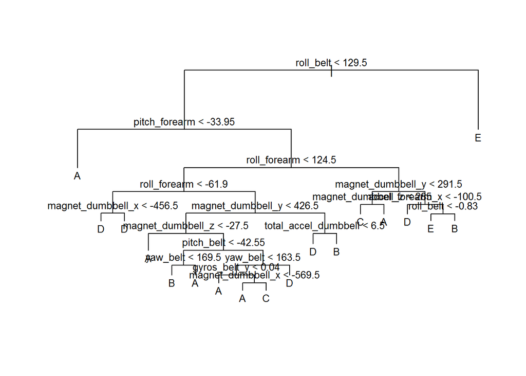

```r
        plot(tree.training)
        text(tree.training, pretty=0, cex =.8)
```

This is a bushy tree, and it needs to be pruned. Print the tree for detailed summary of the tree.

#### 2. Use Rpart form Caret (very slow processing)

```r
library(caret)
set.seed(32323)

        modFit <- train(classe ~ .,method="rpart",data=new_training)
        print(modFit$finalModel)
```

```
## n= 13737
##
## node), split, n, loss, yval, (yprob)
##       * denotes terminal node
##
##  1) root 13737 9831 A (0.28 0.19 0.17 0.16 0.18)
##    2) roll_belt< 129.5 12529 8665 A (0.31 0.21 0.19 0.18 0.11)
##      4) pitch_forearm< -33.95 1090    6 A (0.99 0.0055 0 0 0) *
##      5) pitch_forearm>=-33.95 11439 8659 A (0.24 0.23 0.21 0.2 0.12)
##       10) magnet_dumbbell_y< 426.5 9528 6826 A (0.28 0.18 0.24 0.19 0.11)
##         20) roll_forearm< 122.5 5864 3448 A (0.41 0.18 0.18 0.17 0.057) *
##         21) roll_forearm>=122.5 3664 2447 C (0.078 0.18 0.33 0.23 0.18) *
##       11) magnet_dumbbell_y>=426.5 1911  958 B (0.041 0.5 0.05 0.23 0.18) *
##    3) roll_belt>=129.5 1208   42 E (0.035 0 0 0 0.97) *
```

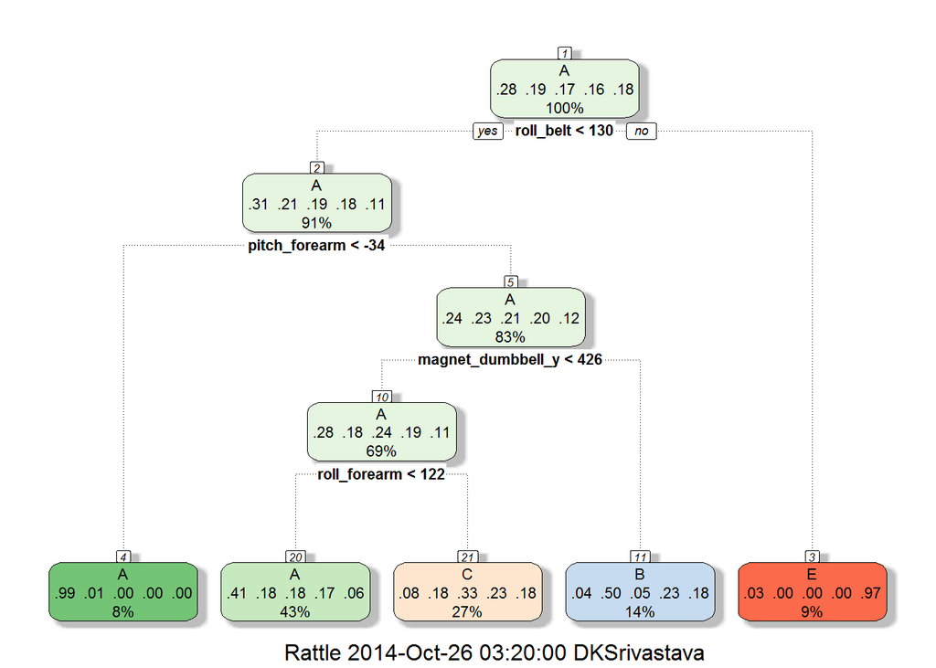

```r
# Draw a Prettier plot

library(rattle)
fancyRpartPlot(modFit$finalModel)
```

The result from ‘caret’ ‘rpart’ package is close to ‘tree’ package.

#### 3. Cross Validation

Check the performance of the tree on the testing data by cross validation.

```r
        tree.pred=predict(tree.training,new_testing,type="class")
        predMatrix = with(new_testing,table(tree.pred,classe))
        sum(diag(predMatrix))/sum(as.vector(predMatrix)) # error rate for tree
```

```
## [1] 0.6720476
```

```r
        tree.pred=predict(modFit,new_testing)
        predMatrix = with(new_testing,table(tree.pred,classe))
        sum(diag(predMatrix))/sum(as.vector(predMatrix)) # error rate for caret
```

```
## [1] 0.4960068
```

#### 4. Pruning the tree

Use Cross Validation to prune the tree.

```r
        cv.training=cv.tree(tree.training,FUN=prune.misclass)
        cv.training
```

```
## $size
##  [1] 18 17 16 15 14 13 12  8  7  6  2  1
##
## $dev
##  [1] 4401 4401 4502 4743 4858 5109 5528 5528 6731 7283 8707 9831
##
## $k
##  [1]    -Inf    0.00  104.00  147.00  169.00  188.00  203.00  211.25
##  [9]  315.00  384.00  486.50 1124.00
##
## $method
## [1] "misclass"
##
## attr(,"class")
## [1] "prune"         "tree.sequence"
```

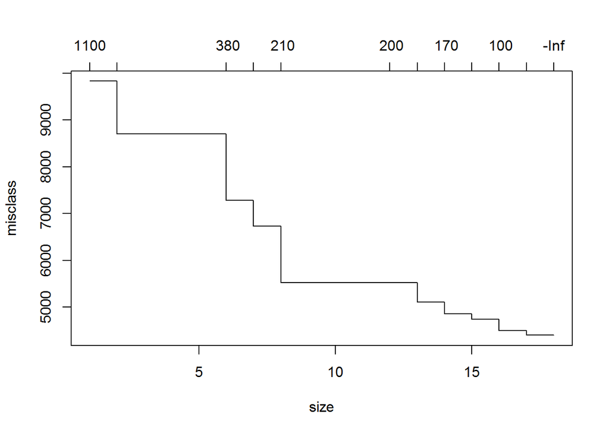

```r
        plot(cv.training)
```

Suppose we prune it at size of nodes at 12.

```r
        prune.training=prune.misclass(tree.training,best=12)
#plot(prune.training);text(prune.training,pretty=0,cex =.8 )
```

Now lets evaluate this pruned tree on the test data.

```r
        tree.pred=predict(prune.training,new_testing,type="class")
        predMatrix = with(new_testing,table(tree.pred,classe))
        sum(diag(predMatrix))/sum(as.vector(predMatrix)) # error rate
```

```
## [1] 0.6207307
```

The single tree is not good enough, so we should use random forests.

### VI. Random Forests

These methods use trees as building blocks to build more complex models.

#### 1. Random Forests

Random forests build lots of bushy trees and then average them to reduce the variance.

```r
library(randomForest)
set.seed(32323)

#Lets fit a random forest and see how well it performs.

        rf.training=randomForest(classe~.,data=new_training,ntree=100, importance=TRUE)
        rf.training
```

```
##
## Call:
##  randomForest(formula = classe ~ ., data = new_training, ntree = 100,      importance = TRUE)
##                Type of random forest: classification
##                      Number of trees: 100
## No. of variables tried at each split: 7
##
##         OOB estimate of  error rate: 0.61%
## Confusion matrix:
##      A    B    C    D    E  class.error
## A 3905    1    0    0    0 0.0002560164
## B   14 2634   10    0    0 0.0090293454
## C    1   15 2373    7    0 0.0095993322
## D    0    0   25 2225    2 0.0119893428
## E    0    2    1    6 2516 0.0035643564
```

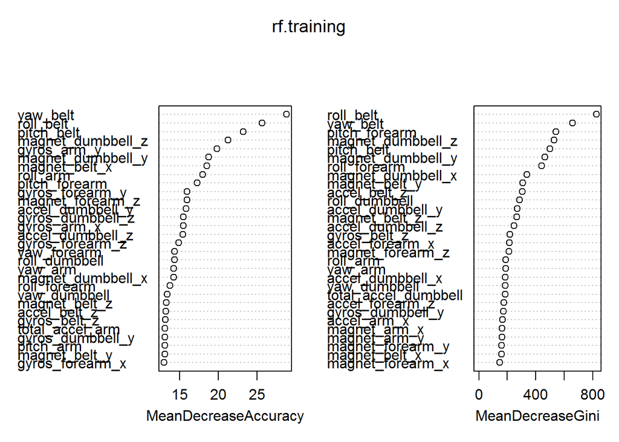

```r
        #plot(rf.training, log="y")
        varImpPlot(rf.training,)
```

```r
        #rf.training1=randomForest(classe~., data=new_training, proximity=TRUE )
        #DSplot(rf.training1, new_training$classe)
```

we can see which variables have higher impact on the prediction.

### VII. Out-of Sample Accuracy

Our Random Forest model shows OOB (out-of-bag) estimate of error rate: 0.61% for the training data. Now we will predict it for out-of sample accuracy.

Lets evaluate this tree on the test data.

```r
        tree.pred=predict(rf.training,new_testing,type="class")
        predMatrix = with(new_testing,table(tree.pred,classe))
        sum(diag(predMatrix))/sum(as.vector(predMatrix)) # error rate
```

```
## [1] 0.995582
```

*0.995582 means we got a very accurate estimate.*

### VIII. Conclusion

Now we can predict the testing data from the website.

```r
        answers <- predict(rf.training, testing)
        answers
```

```
##  1  2  3  4  5  6  7  8  9 10 11 12 13 14 15 16 17 18 19 20
##  B  A  B  A  A  E  D  B  A  A  B  C  B  A  E  E  A  B  B  B
## Levels: A B C D E
```

It shows that this random forest model performed a better job.

.